# R Notebook

> 1. 통계적 비교분석 대상 및 가설설정
> - 계절별(1/8월) 서울시 미세먼지(+초 미세먼지) 농도 분석

#### Discrete Variables

```
+ Null Hypothesis (H0). 계절별(1, 8월)에 따른 서울시 전구역의 미세먼지 수준(Order) 의 차이가 없다.
+ Alternative Hypothesis(H1). 1월과 8월의 서울시 구역의 평균미세먼지 농도의 차이가 있다.(Not Equal)
```

#### Continuous Variables

- Null Hypothesis (H0). 계절별(1, 8월) 의 서울시 구역의 평균 미세먼지 농도의 차이가 없다.
- Alternative Hypothesis (H1-1). 1월과 8월의 서울시 구역의 평균미세먼지 농도의 차이가 있다.(Not Equal)
- Alternative Hypothesis (H1-2). 1월이 8월보다 서울시 전구역의 평균 미세먼지 농도가 더 크다.(Greater)
- Alternative Hypothesis (H1-3). 1월이 8월보다 서울시 전구역의 평균 미세먼지 농도가 더 작다.(Less)
> 2. 유의수준  
>    95% , (Default value, conf.level = 0.95)
> 3. 측정도구
> - 교차분석 - 카이제곱 분석(Chi-square)
> - t.test
> 4. 데이터 수집 & 전처리  
>    서울 열린데이터 광장 (http://data.seoul.go.kr/)
- 데이터 불러오기

```r
#load data. Used opendata in seoul-si
#level of finedust by month, localarea
dust_data <- read.csv("./dust_seoul.csv", header = TRUE)
head(dust_data)
```

|  | 측정일시 | 측정소명 | 이산화질소농도.ppm. | 오존농도.ppm. | 일산화탄소농도.ppm. | 아황산가스.ppm. | 미세먼지..... | 초미세먼지..... |
| --- | --- | --- | --- | --- | --- | --- | --- | --- |
| 1 | 20170613 | 중구 | 0.022 | 0.038 | 0.3 | 0.003 | 27 | 14 |
| 2 | 20170613 | 송파구 | 0.025 | 0.031 | 0.5 | 0.004 | 38 | 16 |
| 3 | 20170613 | 서초구 | 0.022 | 0.034 | 0.4 | 0.005 | 45 | 17 |
| 4 | 20170613 | 종로 | 0.030 | 0.027 | 0.2 | 0.003 | 34 | 19 |
| 5 | 20170613 | 강변북로 | 0.044 | 0.017 | 0.4 | 0.004 | 45 | 17 |
| 6 | 20170613 | 광진구 | 0.021 | 0.032 | 0.4 | 0.005 | 24 | 11 |

```r
summary(dust_data)
```

```
    측정일시           측정소명     이산화질소농도.ppm. 오존농도.ppm.    일산화탄소농도.ppm.
 Min.   :20160613   중구   :  366   Min.   :0.00000     Min.   :0.0000   Min.   :0.100
 1st Qu.:20160912   종로   :  366   1st Qu.:0.02400     1st Qu.:0.0120   1st Qu.:0.400
 Median :20161212   송파구 :  366   Median :0.03400     Median :0.0200   Median :0.500
 Mean   :20165149   서초구 :  366   Mean   :0.03687     Mean   :0.0216   Mean   :0.567
 3rd Qu.:20170314   신촌로 :  366   3rd Qu.:0.04700     3rd Qu.:0.0300   3rd Qu.:0.700
 Max.   :20170613   광진구 :  366   Max.   :0.14000     Max.   :0.2780   Max.   :1.900
                    (Other):12078   NA's   :157         NA's   :153      NA's   :165
 아황산가스.ppm.   미세먼지.....    초미세먼지.....
 Min.   :0.00100   Min.   :  3.00   Min.   :  1.00
 1st Qu.:0.00400   1st Qu.: 34.00   1st Qu.: 18.00
 Median :0.00500   Median : 46.00   Median : 25.00
 Mean   :0.00492   Mean   : 49.83   Mean   : 27.84
 3rd Qu.:0.00600   3rd Qu.: 62.00   3rd Qu.: 35.00
 Max.   :0.01300   Max.   :243.00   Max.   :161.00
 NA's   :142       NA's   :115      NA's   :1031
```

## >5-1. 데이터 코딩/프로그래밍 (상관관계 분석)

### 독립변인 추출.

- 독립변인 : 측정월(1월, 8월)

```r
#Extract monthly info into the month column (substr())
dust_data$month <- substr(dust_data[,1], 5,6)
unique(dust_data$month)
```

```
 [1] "06" "05" "04" "03" "02" "01" "12" "11" "10" "09" "08" "07"
```

```r
names(dust_data) <- c("date","station","Co2.ppm", "Ozone.ppm", "Co.ppm", "SO3.ppm", "Fine.dust", "Ultrafine.dust","month")
#filter by month for 01, 08 (%in%)
dust_data_18 <- subset(dust_data, dust_data$month %in% c('01', '08') )
length(dust_data_18)
```

```
[1] 9
```

```r
dust_data_18
```

|  | date | station | Co2.ppm | Ozone.ppm | Co.ppm | SO3.ppm | Fine.dust | Ultrafine.dust | month |
| --- | --- | --- | --- | --- | --- | --- | --- | --- | --- |
| 5188 | 20170131 | 성동구 | 0.037 | 0.010 | 0.5 | 0.004 | 30 | 17 | 01 |
| 5189 | 20170131 | 금천구 | 0.043 | 0.009 | 0.6 | 0.004 | 26 | 19 | 01 |
| 5190 | 20170131 | 노원구 | 0.036 | 0.013 | 0.7 | 0.003 | 25 | 16 | 01 |
| 5191 | 20170131 | 한강대로 | 0.047 | 0.010 | 0.6 | 0.005 | 37 | 18 | 01 |
| 5192 | 20170131 | 종로구 | 0.038 | 0.012 | 0.5 | 0.003 | 27 | 19 | 01 |
| 5193 | 20170131 | 중구 | 0.037 | 0.012 | 0.5 | 0.003 | 26 | 17 | 01 |
| 5194 | 20170131 | 용산구 | 0.034 | 0.009 | 0.5 | 0.004 | 25 | 17 | 01 |
| 5195 | 20170131 | 광진구 | 0.042 | 0.010 | 0.6 | 0.005 | 33 | 22 | 01 |
| 5196 | 20170131 | 송파구 | 0.042 | 0.007 | 0.7 | 0.004 | 34 | 20 | 01 |
| 5197 | 20170131 | 강서구 | 0.036 | 0.012 | 0.5 | 0.006 | 29 | 17 | 01 |

[output cut: 990 more lines]

### 상관관계 분석

#### 연속값 범주화 (Nominal Variable)

- 미세먼지 농도 분류기준에 따른 상태분류  
  0~30 : ‘good’  
  31~80 : ‘normal’  
  81~ : ‘bad’

```r
dust_data_soup <- dust_data_18[,c("month","Fine.dust","Ultrafine.dust")]
dust_data_soup <- na.omit(dust_data_soup)
dust_data_soup$Fine.dust2[dust_data_soup$Fine.dust <=30] <- 'good'
dust_data_soup$Fine.dust2[dust_data_soup$Fine.dust >=31 & dust_data_soup$Fine.dust <=80] <- 'normal'
dust_data_soup$Fine.dust2[dust_data_soup$Fine.dust >=81 & dust_data_soup$Fine.dust <=150] <- 'bad'
dust_data_soup$Fine.dust2[dust_data_soup$Fine.dust >=151 ] <- 'bad'
dust_data_soup
```

|  | month | Fine.dust | Ultrafine.dust | Fine.dust2 |
| --- | --- | --- | --- | --- |
| 5188 | 01 | 30 | 17 | good |
| 5189 | 01 | 26 | 19 | good |
| 5190 | 01 | 25 | 16 | good |
| 5191 | 01 | 37 | 18 | normal |
| 5192 | 01 | 27 | 19 | good |
| 5193 | 01 | 26 | 17 | good |
| 5194 | 01 | 25 | 17 | good |
| 5195 | 01 | 33 | 22 | normal |
| 5196 | 01 | 34 | 20 | normal |
| 5197 | 01 | 29 | 17 | good |

[output cut: 990 more lines]

#### 교차테이블(Crosstable) 생성 및 Chisquare 값 추출

- table()
- CrossTable from gmodels package

```r
library(gmodels)
month <- dust_data_soup$month
finedust<- dust_data_soup$Fine.dust2
table(month, finedust)
```

```
     finedust
month bad good normal
   01 187  191    700
   08  14  387    800
```

```r
CrossTable(month, finedust, chisq = TRUE)
```

```
   Cell Contents
|-------------------------|
|                       N |
| Chi-square contribution |
|           N / Row Total |
|           N / Col Total |
|         N / Table Total |
|-------------------------|


Total Observations in Table:  2279


             | finedust
       month |       bad |      good |    normal | Row Total |
-------------|-----------|-----------|-----------|-----------|
          01 |       187 |       191 |       700 |      1078 |
             |    88.877 |    24.836 |     0.128 |           |
             |     0.173 |     0.177 |     0.649 |     0.473 |
             |     0.930 |     0.330 |     0.467 |           |
             |     0.082 |     0.084 |     0.307 |           |
-------------|-----------|-----------|-----------|-----------|
          08 |        14 |       387 |       800 |      1201 |
             |    79.774 |    22.292 |     0.115 |           |
             |     0.012 |     0.322 |     0.666 |     0.527 |
             |     0.070 |     0.670 |     0.533 |           |
             |     0.006 |     0.170 |     0.351 |           |
-------------|-----------|-----------|-----------|-----------|
Column Total |       201 |       578 |      1500 |      2279 |
             |     0.088 |     0.254 |     0.658 |           |
-------------|-----------|-----------|-----------|-----------|


Statistics for All Table Factors


Pearson's Chi-squared test
------------------------------------------------------------
Chi^2 =  216.0216     d.f. =  2     p =  1.234518e-47
```

## 6-1. 통계분석 수행(결과 해석, 상관관계 분석)

분석결과 $X^2$ 값은 216, p-value는 $1.234518*10^{-47}$ 이 나왔다.  
이는 자유도 2, 유의수준 0.05에서의 Chi-square 값 5.991 보다 크며 p-value 또한 0.05보다 낮으므로 귀무가설(미세먼지수준과 월별 상관관계는 없다.)이 기각되고 대립가설(미세먼지수준과 월별 상관관계가 있다.)이 채택된다.

## 5-2. 데이터 코딩/프로그래밍 (T-검정)

#### t-검정을 하기 앞서 두 비교집단(1월 미세먼지 / 8월 미세먼지)의 정규성 검사를 실시한다.

#### q-q plot

```r
#Regularity Test - shapiro test
jan <- dust_data_soup$Fine.dust[dust_data_soup$month == '01']
shapiro.test(jan)
```

```
    Shapiro-Wilk normality test

data:  jan
W = 0.91669, p-value < 2.2e-16
```

```r
aug <- dust_data_soup$Fine.dust[dust_data_soup$month == '08']
shapiro.test(aug)
```

```
    Shapiro-Wilk normality test

data:  aug
W = 0.95875, p-value < 2.2e-16
```

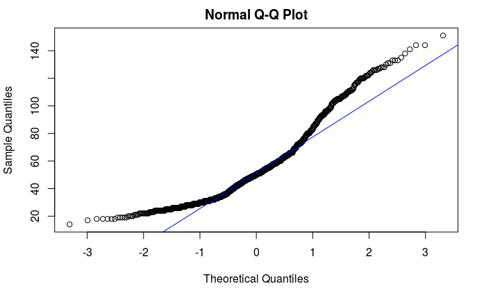

```r
#Q-Q plot(Quantile)
qqnorm(jan)
qqline(jan, lty=1, col="blue")
```

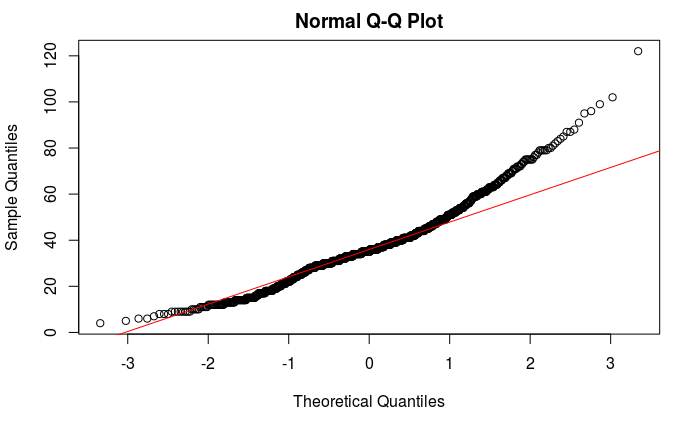

```r
qqnorm(aug)
qqline(aug, lty = 1, col = 'red')
```

```r
#Ordered numbering.
t.test(jan, aug, alternative = "two.sided")
```

```
    Welch Two Sample t-test

data:  jan and aug
t = 19.826, df = 1679.6, p-value < 2.2e-16
alternative hypothesis: true difference in means is not equal to 0
95 percent confidence interval:
 16.68406 20.34758
sample estimates:
mean of x mean of y
 55.63822  37.12240
```

```r
t.test(jan, aug, alternative = "greater")
```

```
    Welch Two Sample t-test

data:  jan and aug
t = 19.826, df = 1679.6, p-value < 2.2e-16
alternative hypothesis: true difference in means is greater than 0
95 percent confidence interval:
 16.97882      Inf
sample estimates:
mean of x mean of y
 55.63822  37.12240
```

```r
t.test(jan, aug, alternative = "less")
```

```
    Welch Two Sample t-test

data:  jan and aug
t = 19.826, df = 1679.6, p-value = 1
alternative hypothesis: true difference in means is less than 0
95 percent confidence interval:
     -Inf 20.05282
sample estimates:
mean of x mean of y
 55.63822  37.12240
```